# Data Visualization in R Using ggplot2 using Airquality Dataset

Josue Iradukunda

2026-11-01

# Introduction

This assignment demonstrates thirteen `ggplot2` geometries using R’s built-in `airquality` dataset. Each geometry creates a different type of visualization or adds a visual element to a plot.

The `airquality` dataset contains daily air-quality measurements in New York from May to September 1973.

## Inspect the data

```r
head(airquality)
```

```
##   Ozone Solar.R Wind Temp Month Day
## 1    41     190  7.4   67     5   1
## 2    36     118  8.0   72     5   2
## 3    12     149 12.6   74     5   3
## 4    18     313 11.5   62     5   4
## 5    NA      NA 14.3   56     5   5
## 6    28      NA 14.9   66     5   6
```

```r
str(airquality)
```

```
## 'data.frame':    153 obs. of  6 variables:
##  $ Ozone  : int  41 36 12 18 NA 28 23 19 8 NA ...
##  $ Solar.R: int  190 118 149 313 NA NA 299 99 19 194 ...
##  $ Wind   : num  7.4 8 12.6 11.5 14.3 14.9 8.6 13.8 20.1 8.6 ...
##  $ Temp   : int  67 72 74 62 56 66 65 59 61 69 ...
##  $ Month  : int  5 5 5 5 5 5 5 5 5 5 ...
##  $ Day    : int  1 2 3 4 5 6 7 8 9 10 ...
```

## Check missing values

```r
colSums(is.na(airquality))
```

```
##   Ozone Solar.R    Wind    Temp   Month     Day
##      37       7       0       0       0       0
```

Some observations contain missing values. For the examples below, `aq` is a complete-case version of the dataset, created with `na.omit()`.

```r
dim(aq)
```

```
## [1] 111   6
```

```r
summary(aq)
```

```
##      Ozone          Solar.R           Wind            Temp             Month
##  Min.   :  1.0   Min.   :  7.0   Min.   : 2.30   Min.   :57.00   May      :24
##  1st Qu.: 18.0   1st Qu.:113.5   1st Qu.: 7.40   1st Qu.:71.00   June     : 9
##  Median : 31.0   Median :207.0   Median : 9.70   Median :79.00   July     :26
##  Mean   : 42.1   Mean   :184.8   Mean   : 9.94   Mean   :77.79   August   :23
##  3rd Qu.: 62.0   3rd Qu.:255.5   3rd Qu.:11.50   3rd Qu.:84.50   September:29
##  Max.   :168.0   Max.   :334.0   Max.   :20.70   Max.   :97.00
##       Day
##  Min.   : 1.00
##  1st Qu.: 9.00
##  Median :16.00
##  Mean   :15.95
##  3rd Qu.:22.50
##  Max.   :31.00
```

# Visualizations using ggplot2 geometries

## 1. `geom_bar()` — Bar chart

`geom_bar()` counts the number of observations in each category by default. Here, it shows how many daily records are available for each month.

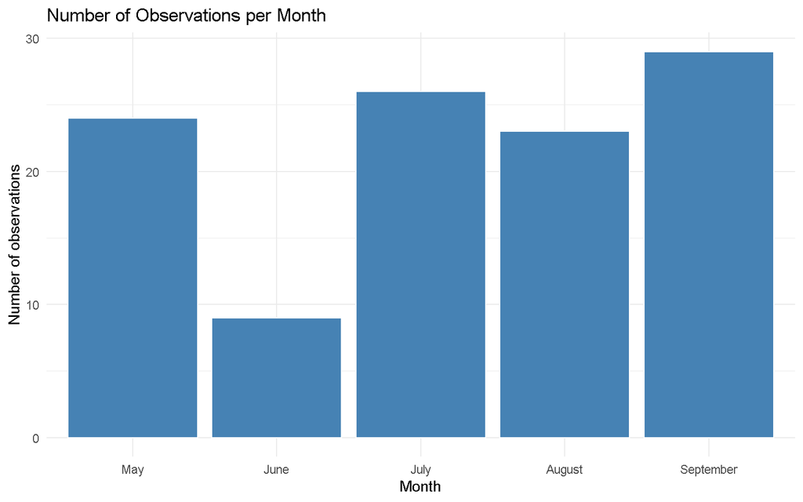

Number of observations in each month.

```r
ggplot(aq, aes(x = Month)) +
  geom_bar(fill = "steelblue", color = "white") +
  labs(
    title = "Number of Observations per Month",
    x = "Month",
    y = "Number of observations"
  ) +
  theme_minimal()
```

**Interpretation:** Each bar represents the number of complete daily records for that month.

## 2. `geom_boxplot()` — Boxplot

`geom_boxplot()` summarizes the distribution of a numerical variable using the median, quartiles, whiskers, and potential outliers.

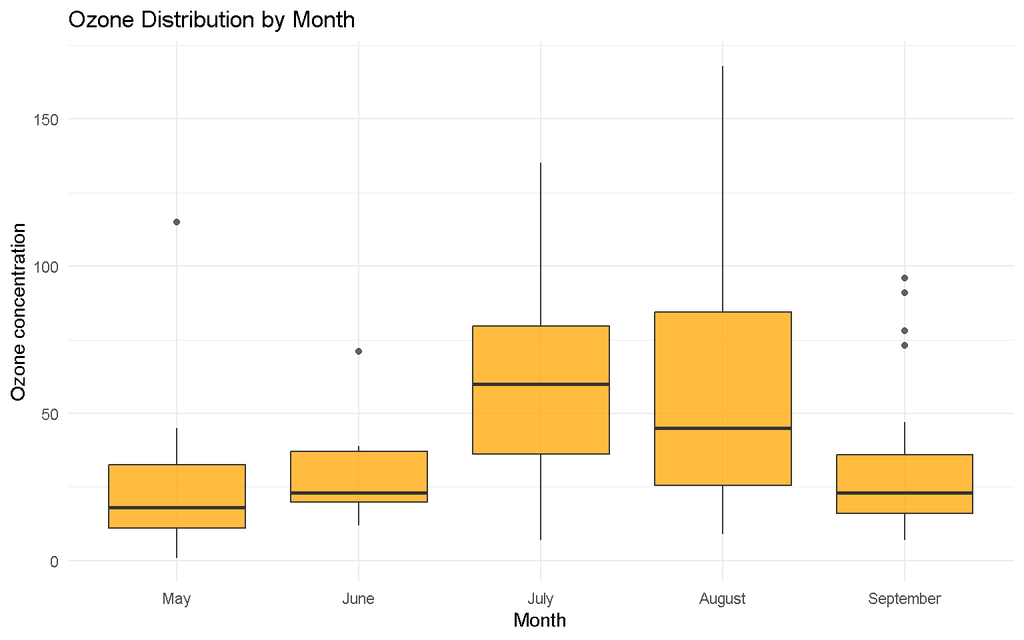

Distribution of ozone measurements by month.

```r
ggplot(aq, aes(x = Month, y = Ozone)) +
  geom_boxplot(fill = "orange", alpha = 0.75) +
  labs(
    title = "Ozone Distribution by Month",
    x = "Month",
    y = "Ozone concentration"
  ) +
  theme_minimal()
```

**Interpretation:** Compare the median ozone level, spread, and potential outliers across the months.

## 3. `geom_density()` — Density plot

`geom_density()` estimates and displays the distribution of a continuous numerical variable as a smooth curve.

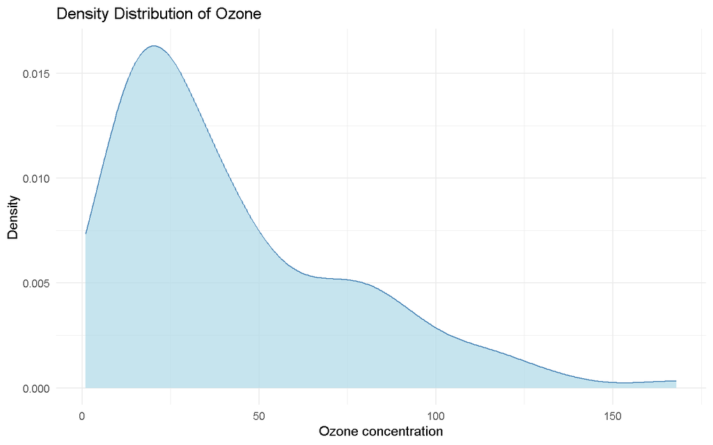

Estimated density distribution of ozone measurements.

```r
ggplot(aq, aes(x = Ozone)) +
  geom_density(fill = "lightblue", color = "steelblue", alpha = 0.7) +
  labs(
    title = "Density Distribution of Ozone",
    x = "Ozone concentration",
    y = "Density"
  ) +
  theme_minimal()
```

**Interpretation:** Higher parts of the curve indicate ozone values where observations are more concentrated.

## 4. `geom_histogram()` — Histogram

`geom_histogram()` divides a numerical variable into intervals (bins) and displays the number of observations in each interval.

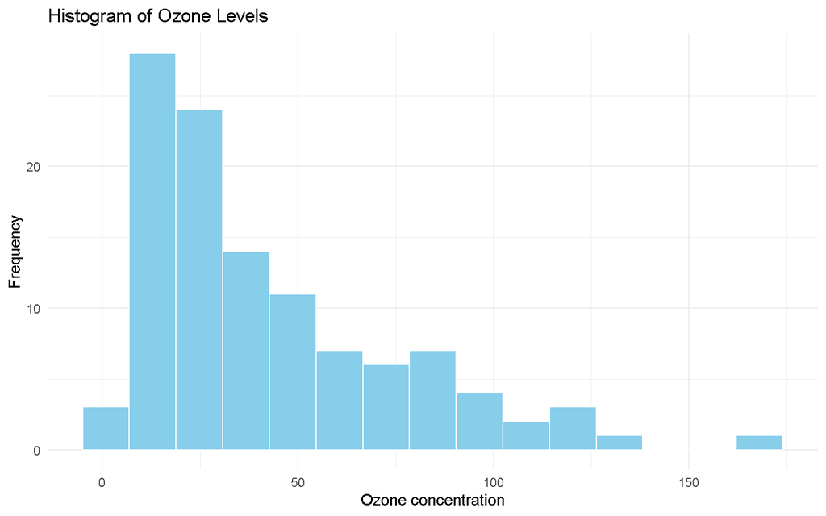

Frequency distribution of ozone measurements.

```r
ggplot(aq, aes(x = Ozone)) +
  geom_histogram(
    bins = 15,
    fill = "skyblue",
    color = "white"
  ) +
  labs(
    title = "Histogram of Ozone Levels",
    x = "Ozone concentration",
    y = "Frequency"
  ) +
  theme_minimal()
```

**Interpretation:** The bars show how frequently ozone measurements fall within each interval. Changing `bins` changes the number of intervals.

## 5. `geom_hline()` — Horizontal reference line

`geom_hline()` adds a horizontal line at a specified y-value. In this example, the line marks the mean ozone concentration.

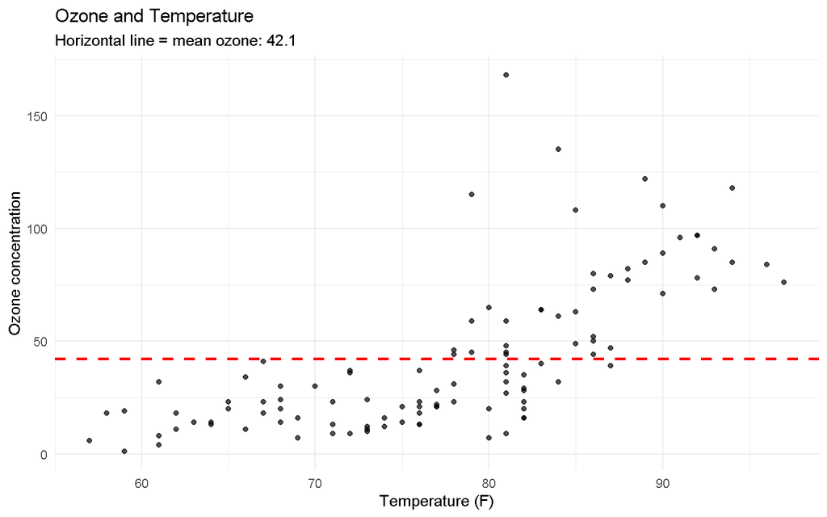

Ozone and temperature with a horizontal mean reference line.

```r
mean_ozone <- mean(aq$Ozone)

ggplot(aq, aes(x = Temp, y = Ozone)) +
  geom_point(alpha = 0.7) +
  geom_hline(
    yintercept = mean_ozone,
    color = "red",
    linewidth = 1,
    linetype = "dashed"
  ) +
  labs(
    title = "Ozone and Temperature",
    subtitle = paste("Horizontal line = mean ozone:", round(mean_ozone, 1)),
    x = "Temperature (F)",
    y = "Ozone concentration"
  ) +
  theme_minimal()
```

**Interpretation:** Points above the line have ozone values greater than the dataset’s mean; points below it have values lower than the mean.

## 6. `geom_jitter()` — Jitter plot

`geom_jitter()` adds a small amount of random displacement to points. This helps reveal observations that would otherwise overlap.

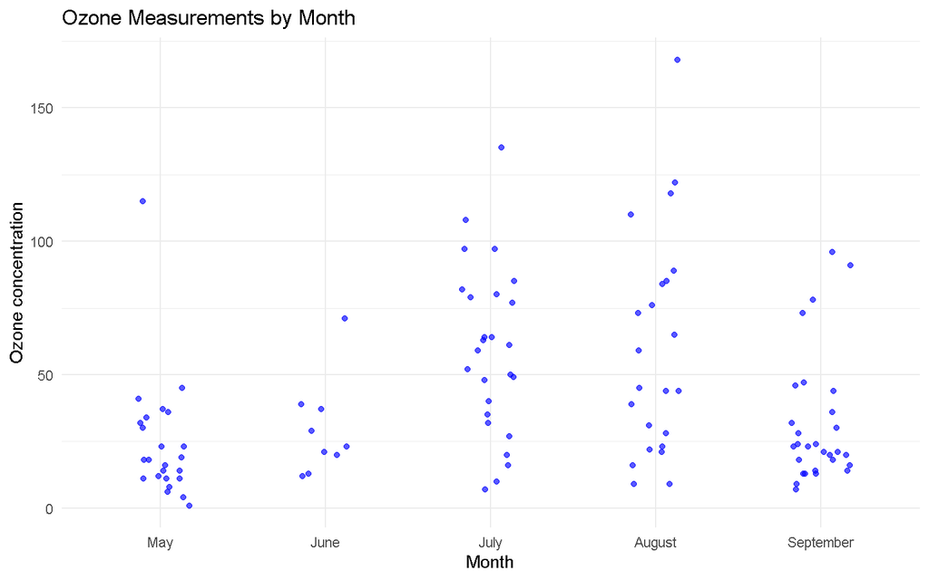

Ozone measurements by month with jitter to reduce overlap.

```r
ggplot(aq, aes(x = Month, y = Ozone)) +
  geom_jitter(
    color = "blue",
    width = 0.18,
    height = 0,
    alpha = 0.65
  ) +
  labs(
    title = "Ozone Measurements by Month",
    x = "Month",
    y = "Ozone concentration"
  ) +
  theme_minimal()
```

**Interpretation:** The horizontal jitter separates points visually. It does not change the original ozone measurements.

## 7. `geom_line()` — Line graph

`geom_line()` connects observations in x-axis order. Here, each month is displayed as a separate series of daily temperatures.

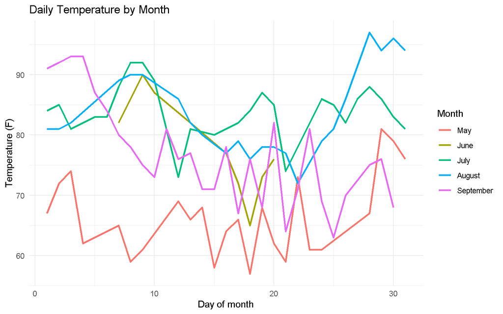

Daily temperature observations, grouped by month.

```r
ggplot(aq, aes(x = Day, y = Temp, color = Month, group = Month)) +
  geom_line(linewidth = 0.9) +
  labs(
    title = "Daily Temperature by Month",
    x = "Day of month",
    y = "Temperature (F)",
    color = "Month"
  ) +
  theme_minimal()
```

**Interpretation:** Each coloured line represents one month. The plot allows us to compare daily temperature patterns, although the same day number in different months does not represent the same date.

## 8. `geom_point()` — Scatter plot

`geom_point()` displays each observation as a point. It is commonly used to explore the relationship between two numerical variables.

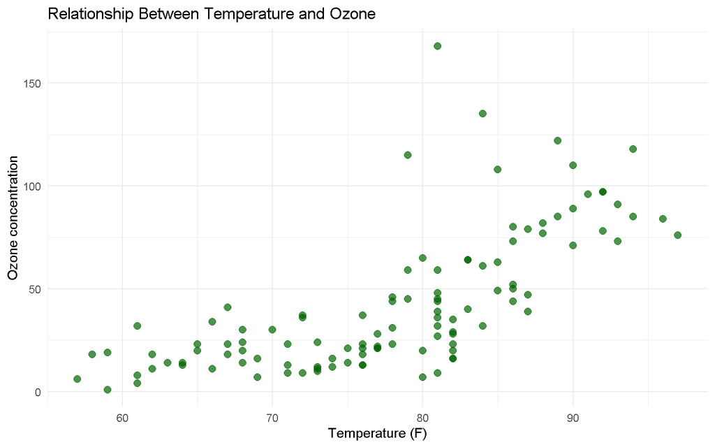

Relationship between temperature and ozone.

```r
ggplot(aq, aes(x = Temp, y = Ozone)) +
  geom_point(color = "darkgreen", size = 2.5, alpha = 0.7) +
  labs(
    title = "Relationship Between Temperature and Ozone",
    x = "Temperature (F)",
    y = "Ozone concentration"
  ) +
  theme_minimal()
```

**Interpretation:** Look for an overall pattern in the points. An upward pattern may suggest that higher temperatures are associated with higher ozone measurements; a scatter plot alone does not establish causation.

## 9. `geom_rug()` — Rug plot

`geom_rug()` adds small marks along the plot axes to show the locations of individual observations.

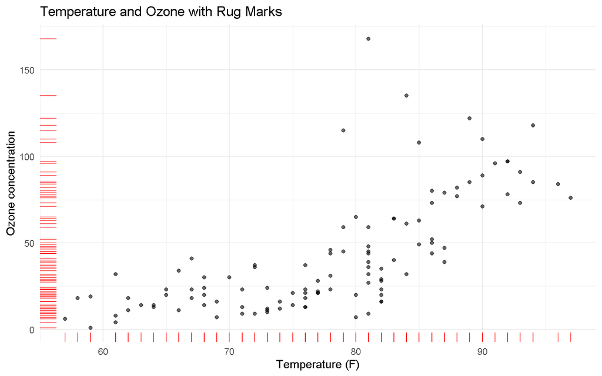

Scatter plot with rug marks along both axes.

```r
ggplot(aq, aes(x = Temp, y = Ozone)) +
  geom_point(alpha = 0.6) +
  geom_rug(color = "red", alpha = 0.6) +
  labs(
    title = "Temperature and Ozone with Rug Marks",
    x = "Temperature (F)",
    y = "Ozone concentration"
  ) +
  theme_minimal()
```

**Interpretation:** The marks along the bottom and left edges show where observations occur on the temperature and ozone scales.

## 10. `geom_smooth()` — Smoothed trend

`geom_smooth()` adds an estimated trend line. The `loess` method is useful for showing a potentially nonlinear pattern in this dataset.

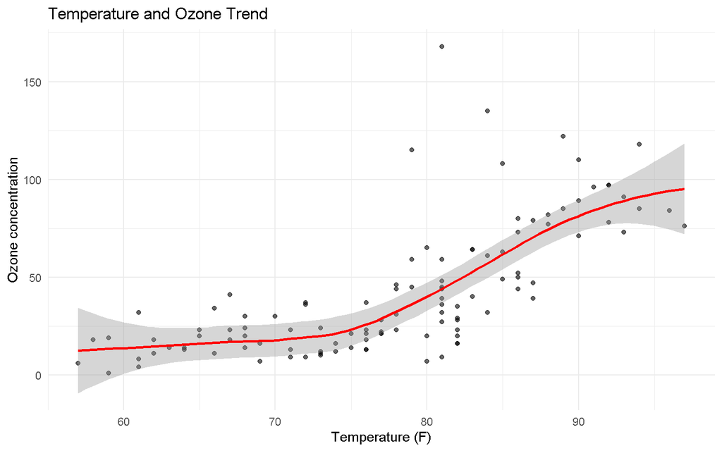

Smoothed relationship between temperature and ozone.

```r
ggplot(aq, aes(x = Temp, y = Ozone)) +
  geom_point(alpha = 0.6) +
  geom_smooth(
    method = "loess",
    color = "red",
    se = TRUE
  ) +
  labs(
    title = "Temperature and Ozone Trend",
    x = "Temperature (F)",
    y = "Ozone concentration"
  ) +
  theme_minimal()
```

**Interpretation:** The curve summarizes the estimated relationship. The shaded area is the confidence band around the fitted smooth.

## 11. `geom_text()` — Text labels

`geom_text()` places text at specified coordinates. This example adds an annotation to the scatter plot.

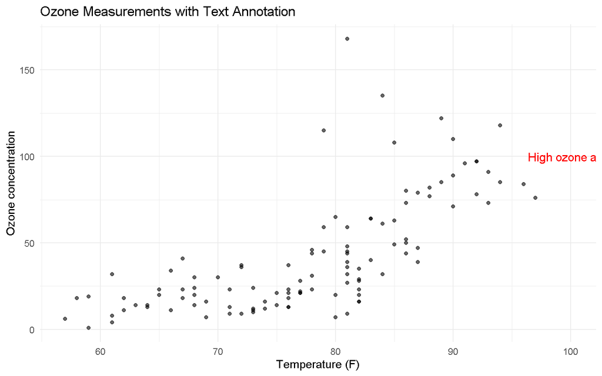

Scatter plot with a text annotation.

```r
ggplot(aq, aes(x = Temp, y = Ozone)) +
  geom_point(alpha = 0.6) +
  annotate(
    "text",
    x = 100,
    y = 100,
    label = "High ozone area",
    color = "red",
    size = 4
  ) +
  labs(
    title = "Ozone Measurements with Text Annotation",
    x = "Temperature (F)",
    y = "Ozone concentration"
  ) +
  theme_minimal()
```

**Interpretation:** The annotation adds explanatory text at the chosen coordinates. Its position is illustrative and is not itself a data point.

## 12. `geom_violin()` — Violin plot

`geom_violin()` displays the distribution of a numerical variable across categories. The width of the violin represents the estimated data density.

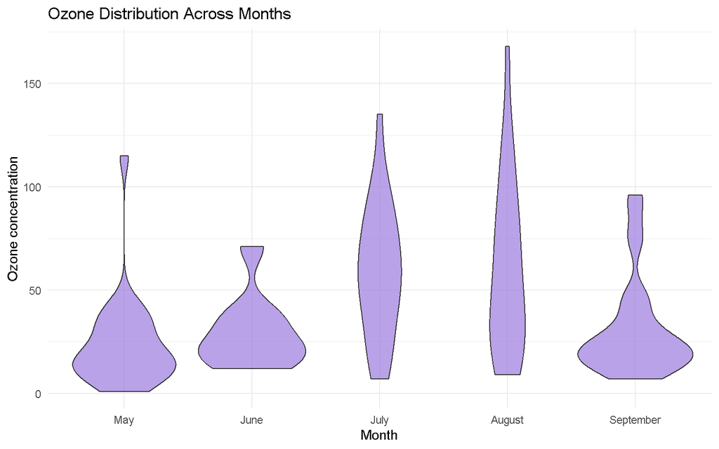

Distribution of ozone measurements across months.

```r
ggplot(aq, aes(x = Month, y = Ozone)) +
  geom_violin(fill = "mediumpurple", alpha = 0.65, na.rm = TRUE) +
  labs(
    title = "Ozone Distribution Across Months",
    x = "Month",
    y = "Ozone concentration"
  ) +
  theme_minimal()
```

**Interpretation:** Wider sections indicate ozone values with a higher estimated concentration of observations. Compare the shapes across months.

## 13. `geom_vline()` — Vertical reference line

`geom_vline()` adds a vertical line at a specified x-value. Here, the line marks the mean temperature.

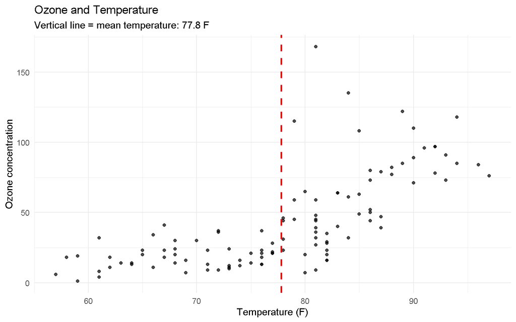

Ozone and temperature with a vertical mean reference line.

```r
mean_temp <- mean(aq$Temp)

ggplot(aq, aes(x = Temp, y = Ozone)) +
  geom_point(alpha = 0.7) +
  geom_vline(
    xintercept = mean_temp,
    color = "red",
    linewidth = 1,
    linetype = "dashed"
  ) +
  labs(
    title = "Ozone and Temperature",
    subtitle = paste("Vertical line = mean temperature:", round(mean_temp, 1), "F"),
    x = "Temperature (F)",
    y = "Ozone concentration"
  ) +
  theme_minimal()
```

**Interpretation:** Observations to the left of the line have temperatures below the mean; observations to the right have temperatures above the mean.